# Películas de éxito

Los datos en este estudio comprenden las características y clasificaciones de películas recopiladas principalmente de dos páginas web: IMDB y Rotten Tomatoes. Los datos contienen 651 películas elegidas al azar.

En este estudio, queremos analizar si la popularidad de una película (audience_score) se basa realmente en variables como: critics score, audience rating, critics rating,imdb rating, imdb number of votes, genre, runtime, title type, Oscar awards won (actor, actress, director and picture). O si otras variables como ser la secuela de una película exitosa o tener una popularidad positiva, etc., también juegan un papel importante.

SE quiere entrenar un modelo que nos permita predecir si una pelicula tendrá exito, ya que predecir la popularidad de una película, será una gran ventaja para Paramount Pictures para determinar sus producciones en el futuro.

- title: Title of movie
- title_type: Type of movie (Documentary, Feature Film, TV Movie)
- genre: Genre of movie (Action & Adventure, Comedy, Documentary, Drama, Horror, Mystery & Suspense, Other)
- runtime: Runtime of movie (in minutes)
- imdb_rating: Rating on IMDB
- imdb_num_votes: Number of votes on IMDB
- critics_rating: Categorical variable for critics rating on Rotten Tomatoes (Certified Fresh, Fresh, Rotten)
- critics_score: Critics score on Rotten Tomatoes
- audience_rating: Categorical variable for audience rating on Rotten Tomatoes (Spilled, Upright)
- audience_score: Audience score on Rotten Tomatoes
- best_pic_nom: Whether or not the movie was nominated for a best picture Oscar (no, yes)
- best_pic_win: Whether or not the movie won a best picture Oscar (no, yes)
- best_actor_win: Whether or not one of the main actors in the movie ever won an Oscar (no, yes) – note that this is not necessarily whether the actor won an Oscar for their role in the given movie
- best_actress_win: Whether or not one of the main actresses in the movie ever won an Oscar (no, yes) – not that this is not necessarily whether the actresses won an Oscar for their role in the given movie
- best_dir_win: Whether or not the director of the movie ever won an Oscar (no, yes) – not that this is not necessarily whether the director won an Oscar for the given movie

Cargamos las librerias necesarias:

```r
library(ggplot2)
library(dplyr)
library(corrplot)
library(caret)
library(statsr)
library(gridExtra)
library(GGally)
library(ggthemes)
library(DMwR)
```

# Cargar el dataset

Cargamos el fichero:

```r
load("movies.Rdata")
summary(movies)
```

```
    title                  title_type                 genre        runtime       mpaa_rating
 Length:651         Documentary : 55   Drama             :305   Min.   : 39.0   G      : 19
 Class :character   Feature Film:591   Comedy            : 87   1st Qu.: 92.0   NC-17  :  2
 Mode  :character   TV Movie    :  5   Action & Adventure: 65   Median :103.0   PG     :118
                                       Mystery & Suspense: 59   Mean   :105.8   PG-13  :133
                                       Documentary       : 52   3rd Qu.:115.8   R      :329
                                       Horror            : 23   Max.   :267.0   Unrated: 50
                                       (Other)           : 60   NA's   :1
                              studio    thtr_rel_year  thtr_rel_month   thtr_rel_day
 Paramount Pictures              : 37   Min.   :1970   Min.   : 1.00   Min.   : 1.00
 Warner Bros. Pictures           : 30   1st Qu.:1990   1st Qu.: 4.00   1st Qu.: 7.00
 Sony Pictures Home Entertainment: 27   Median :2000   Median : 7.00   Median :15.00
 Universal Pictures              : 23   Mean   :1998   Mean   : 6.74   Mean   :14.42
 Warner Home Video               : 19   3rd Qu.:2007   3rd Qu.:10.00   3rd Qu.:21.00
 (Other)                         :507   Max.   :2014   Max.   :12.00   Max.   :31.00
 NA's                            :  8
  dvd_rel_year  dvd_rel_month     dvd_rel_day     imdb_rating    imdb_num_votes
 Min.   :1991   Min.   : 1.000   Min.   : 1.00   Min.   :1.900   Min.   :   180
 1st Qu.:2001   1st Qu.: 3.000   1st Qu.: 7.00   1st Qu.:5.900   1st Qu.:  4546
 Median :2004   Median : 6.000   Median :15.00   Median :6.600   Median : 15116
 Mean   :2004   Mean   : 6.333   Mean   :15.01   Mean   :6.493   Mean   : 57533
 3rd Qu.:2008   3rd Qu.: 9.000   3rd Qu.:23.00   3rd Qu.:7.300   3rd Qu.: 58300
 Max.   :2015   Max.   :12.000   Max.   :31.00   Max.   :9.000   Max.   :893008
 NA's   :8      NA's   :8        NA's   :8
         critics_rating critics_score    audience_rating audience_score  best_pic_nom best_pic_win
 Certified Fresh:135    Min.   :  1.00   Spilled:275     Min.   :11.00   no :629      no :644
 Fresh          :209    1st Qu.: 33.00   Upright:376     1st Qu.:46.00   yes: 22      yes:  7
 Rotten         :307    Median : 61.00                   Median :65.00
                        Mean   : 57.69                   Mean   :62.36
                        3rd Qu.: 83.00                   3rd Qu.:80.00
                        Max.   :100.00                   Max.   :97.00

 best_actor_win best_actress_win best_dir_win top200_box   director            actor1
 no :558        no :579          no :608      no :636    Length:651         Length:651
 yes: 93        yes: 72          yes: 43      yes: 15    Class :character   Class :character
                                                         Mode  :character   Mode  :character




    actor2             actor3             actor4             actor5            imdb_url
 Length:651         Length:651         Length:651         Length:651         Length:651
 Class :character   Class :character   Class :character   Class :character   Class :character
 Mode  :character   Mode  :character   Mode  :character   Mode  :character   Mode  :character




    rt_url
 Length:651
 Class :character
 Mode  :character
```

```r
head(movies)
```

| title | title_type | genre | runtime | mpaa_rating | studio | thtr_rel_year | thtr_rel_month | thtr_rel_day | dvd_rel_year | dvd_rel_month | dvd_rel_day | imdb_rating | imdb_num_votes | critics_rating | critics_score | audience_rating | audience_score | best_pic_nom | best_pic_win | best_actor_win | best_actress_win | best_dir_win | top200_box | director | actor1 | actor2 | actor3 | actor4 | actor5 | … |
| --- | --- | --- | --- | --- | --- | --- | --- | --- | --- | --- | --- | --- | --- | --- | --- | --- | --- | --- | --- | --- | --- | --- | --- | --- | --- | --- | --- | --- | --- | --- |
| Filly Brown | Feature Film | Drama | 80 | R | Indomina Media Inc. | 2013 | 4 | 19 | 2013 | 7 | 30 | 5.5 | 899 | Rotten | 45 | Upright | 73 | no | no | no | no | no | no | Michael D. Olmos | Gina Rodriguez | Jenni Rivera | Lou Diamond Phillips | Emilio Rivera | Joseph Julian Soria | … |
| The Dish | Feature Film | Drama | 101 | PG-13 | Warner Bros. Pictures | 2001 | 3 | 14 | 2001 | 8 | 28 | 7.3 | 12285 | Certified Fresh | 96 | Upright | 81 | no | no | no | no | no | no | Rob Sitch | Sam Neill | Kevin Harrington | Patrick Warburton | Tom Long | Genevieve Mooy | … |
| Waiting for Guffman | Feature Film | Comedy | 84 | R | Sony Pictures Classics | 1996 | 8 | 21 | 2001 | 8 | 21 | 7.6 | 22381 | Certified Fresh | 91 | Upright | 91 | no | no | no | no | no | no | Christopher Guest | Christopher Guest | Catherine O'Hara | Parker Posey | Eugene Levy | Bob Balaban | … |
| The Age of Innocence | Feature Film | Drama | 139 | PG | Columbia Pictures | 1993 | 10 | 1 | 2001 | 11 | 6 | 7.2 | 35096 | Certified Fresh | 80 | Upright | 76 | no | no | yes | no | yes | no | Martin Scorsese | Daniel Day-Lewis | Michelle Pfeiffer | Winona Ryder | Richard E. Grant | Alec McCowen | … |
| Malevolence | Feature Film | Horror | 90 | R | Anchor Bay Entertainment | 2004 | 9 | 10 | 2005 | 4 | 19 | 5.1 | 2386 | Rotten | 33 | Spilled | 27 | no | no | no | no | no | no | Stevan Mena | Samantha Dark | R. Brandon Johnson | Brandon Johnson | Heather Magee | Richard Glover | … |
| Old Partner | Documentary | Documentary | 78 | Unrated | Shcalo Media Group | 2009 | 1 | 15 | 2010 | 4 | 20 | 7.8 | 333 | Fresh | 91 | Upright | 86 | no | no | no | no | no | no | Chung-ryoul Lee | Choi Won-kyun | Lee Sam-soon | Moo | NA | NA | … |

```r
movies_new <- movies [,c('runtime', 'imdb_rating', 'imdb_num_votes', 'critics_rating', 'critics_score', 'audience_rating', 'audience_score', 'best_pic_win', 'best_actor_win', 'best_actress_win', 'best_dir_win')]
head(movies_new)
```

| runtime | imdb_rating | imdb_num_votes | critics_rating | critics_score | audience_rating | audience_score | best_pic_win | best_actor_win | best_actress_win | best_dir_win |
| --- | --- | --- | --- | --- | --- | --- | --- | --- | --- | --- |
| 80 | 5.5 | 899 | Rotten | 45 | Upright | 73 | no | no | no | no |
| 101 | 7.3 | 12285 | Certified Fresh | 96 | Upright | 81 | no | no | no | no |
| 84 | 7.6 | 22381 | Certified Fresh | 91 | Upright | 91 | no | no | no | no |
| 139 | 7.2 | 35096 | Certified Fresh | 80 | Upright | 76 | no | yes | no | yes |
| 90 | 5.1 | 2386 | Rotten | 33 | Spilled | 27 | no | no | no | no |
| 78 | 7.8 | 333 | Fresh | 91 | Upright | 86 | no | no | no | no |

```r
str(movies_new)
```

```
Classes ‘tbl_df’, ‘tbl’ and 'data.frame':   651 obs. of  11 variables:
 $ runtime         : num  80 101 84 139 90 78 142 93 88 119 ...
 $ imdb_rating     : num  5.5 7.3 7.6 7.2 5.1 7.8 7.2 5.5 7.5 6.6 ...
 $ imdb_num_votes  : int  899 12285 22381 35096 2386 333 5016 2272 880 12496 ...
 $ critics_rating  : Factor w/ 3 levels "Certified Fresh",..: 3 1 1 1 3 2 3 3 2 1 ...
 $ critics_score   : num  45 96 91 80 33 91 57 17 90 83 ...
 $ audience_rating : Factor w/ 2 levels "Spilled","Upright": 2 2 2 2 1 2 2 1 2 2 ...
 $ audience_score  : num  73 81 91 76 27 86 76 47 89 66 ...
 $ best_pic_win    : Factor w/ 2 levels "no","yes": 1 1 1 1 1 1 1 1 1 1 ...
 $ best_actor_win  : Factor w/ 2 levels "no","yes": 1 1 1 2 1 1 1 2 1 1 ...
 $ best_actress_win: Factor w/ 2 levels "no","yes": 1 1 1 1 1 1 1 1 1 1 ...
 $ best_dir_win    : Factor w/ 2 levels "no","yes": 1 1 1 2 1 1 1 1 1 1 ...
```

```r
summary(movies_new)
```

```
    runtime       imdb_rating    imdb_num_votes           critics_rating critics_score
 Min.   : 39.0   Min.   :1.900   Min.   :   180   Certified Fresh:135    Min.   :  1.00
 1st Qu.: 92.0   1st Qu.:5.900   1st Qu.:  4546   Fresh          :209    1st Qu.: 33.00
 Median :103.0   Median :6.600   Median : 15116   Rotten         :307    Median : 61.00
 Mean   :105.8   Mean   :6.493   Mean   : 57533                          Mean   : 57.69
 3rd Qu.:115.8   3rd Qu.:7.300   3rd Qu.: 58300                          3rd Qu.: 83.00
 Max.   :267.0   Max.   :9.000   Max.   :893008                          Max.   :100.00
 NA's   :1
 audience_rating audience_score  best_pic_win best_actor_win best_actress_win best_dir_win
 Spilled:275     Min.   :11.00   no :644      no :558        no :579          no :608
 Upright:376     1st Qu.:46.00   yes:  7      yes: 93        yes: 72          yes: 43
                 Median :65.00
                 Mean   :62.36
                 3rd Qu.:80.00
                 Max.   :97.00
```

Habiendo visto el summary, queremos comprobar que no hayan valores nulos en el dataset, ya que esto pudiera hacer que el estudio sea erroneo.

```r
#Primero vemos si hay nulos
any(is.na(movies_new))
```

```
[1] TRUE
```

```r
#Ahora vemos cuantos nulos hay
sum(any(is.na(movies_new)))
```

```
[1] 1
```

```r
#Hay solo 1 nulo, por tanto lo eliminamos...
mset <- na.omit(movies_new)
```

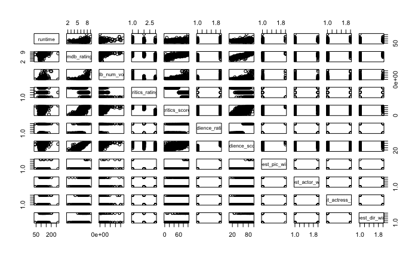

```r
#Tenemos la siguiente dependencia..
library(psych)
#Ahora graficamos!
#multi.hist(x = movies, dcol = c("blue", "red"), dlty = c("dotted", "solid"))
#Nos da error (obviamente), porque la mayoria de nuestras variables son strings y no numericas
#y por tanto graficamos para ver correlaciones como en estadistica industrial
plot(mset)
```

Ahora dividiremos los datos en training y testing sets (asi es como alimentaremos a nuestro algoritmo)

```r
# We start the list of random numbers at the position 123
set.seed(123)
validation_index <- createDataPartition(mset$audience_score, p=0.75, list=FALSE)
# select 20% of the data for validation
trainset <- mset[-validation_index,]
# use the remaining 80% of data to training and testing the models
testset <- mset[validation_index,]
```

```r
#Misma formula de estadistica para reg multiple, la diferencia es que lo haremos con el training set
modelo <- lm(formula = audience_score ~ ., data = trainset)
summary(modelo)
```

```
Call:
lm(formula = audience_score ~ ., data = trainset)

Residuals:
     Min       1Q   Median       3Q      Max
-15.3218  -4.8107   0.9328   4.0272  17.3733

Coefficients:
                         Estimate Std. Error t value Pr(>|t|)
(Intercept)            -9.543e+00  5.556e+00  -1.718    0.088 .
runtime                 2.041e-02  3.745e-02   0.545    0.587
imdb_rating             9.135e+00  8.873e-01  10.295   <2e-16 ***
imdb_num_votes          2.767e-06  5.997e-06   0.461    0.645
critics_ratingFresh     3.151e-01  1.852e+00   0.170    0.865
critics_ratingRotten   -1.827e+00  2.920e+00  -0.626    0.532
critics_score          -6.349e-03  5.455e-02  -0.116    0.908
audience_ratingUpright  2.056e+01  1.558e+00  13.198   <2e-16 ***
best_pic_winyes         3.025e+00  3.809e+00   0.794    0.428
best_actor_winyes      -4.755e-01  1.587e+00  -0.300    0.765
best_actress_winyes    -1.876e+00  1.616e+00  -1.161    0.247
best_dir_winyes        -4.095e-01  2.308e+00  -0.177    0.859
---
Signif. codes:  0 ‘***’ 0.001 ‘**’ 0.01 ‘*’ 0.05 ‘.’ 0.1 ‘ ’ 1

Residual standard error: 6.774 on 148 degrees of freedom
Multiple R-squared:  0.9054,    Adjusted R-squared:  0.8984
F-statistic: 128.8 on 11 and 148 DF,  p-value: < 2.2e-16
```

Ahora graficamos el modelo

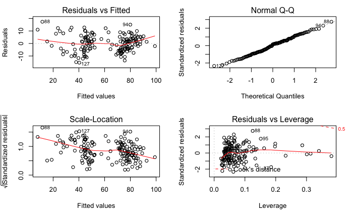

```r
#Misma formula de estadistica para reg multiple, la diferencia es que lo haremos con el training set
par(mfrow = c(2,2))
plot(modelo)
```

Podemos ver que los graficos se ven prometedores (los residuos se ven normales y siguen distribucion normal segun nuestro Q-Q plot)

Ahora queremos predecir a partir del modelo

```r
#Usamos 95% de confianza
prediccion <- predict(object = modelo, newdata = testset, llevel = 0.95)
print(prediccion)
```

[output not shown]

[output cut: 35 more lines]

[output not shown]

Usaremos este modelo que acabamos de obtener con mi sample de testeo

```r
comp <- data.frame(cbind(actuals = testset$audience_score, predicted = prediccion))
comp
```

|  | actuals | predicted |
| --- | --- | --- |
| 1 | 91 | 81.64728 |
| 2 | 76 | 78.33567 |
| 3 | 86 | 83.60595 |
| 4 | 76 | 77.51779 |
| 5 | 47 | 40.19588 |
| 6 | 89 | 81.07728 |
| 7 | 75 | 74.89106 |
| 8 | 53 | 44.48271 |
| 9 | 64 | 74.80987 |
| 10 | 80 | 77.25659 |

[output cut: 480 more lines]

Con esto, podemos obtener el error del test..

```r
testerr
```

[output not shown]

```
      mae       mse      rmse      mape
 5.515559 50.371188  7.097266  0.112732
```

Y tambien podemos obtener el training error rate

```r
modeloTrain <- predict(object = modelo, newdata = trainset, level = 0.95)
compTrainer <- data.frame(cbind(actuals = trainset$audience_score, predicted = modeloTrain, level = 0.95))
trainerr <- regr.eval(compTrainer$actuals, compTrainer$predicted)

trainerr
```

```
       mae        mse       rmse       mape
 5.3810345 42.4511820  6.5154572  0.1146759
```